# Marginal effect model

Felicia Francis Immanuel

2025-12-18

## Interpreting GLMM coefficients with marginal effects

Our outcome is binary (`related = 1` vs `related = 0`), so we fit a logistic GLMM.  
In a logistic model, coefficients are on the log-odds scale:

$$\text{logit}(p) = \log\left(\frac{p}{1-p}\right) = \eta = \beta_0 +
\beta_1 x_1 + \dots$$

Exponentiating a coefficient gives an odds ratio:

$$\exp(\beta_k) = \text{odds ratio}$$

This is not the same as “times more likely” in terms of probability.  
The same odds ratio can correspond to very different probability changes depending on the baseline probability $p$. Therefore, interpreting $\exp(\beta)$ as a direct multiplier of probability can be misleading when baseline probabilities are small.

## Marginal Effect

A marginal effect translates the model from the log-odds scale to the probability scale.  
It answers the question:

> “Holding other variables constant, how much does the predicted probability $P(\text{related}=1)$ change when a predictor changes?”

For a continuous predictor $x$, the (instantaneous) marginal effect is:

$$\frac{\partial p}{\partial x}$$

For a categorical predictor (e.g., sex-pair group), the marginal effect is typically reported as a discrete change:

$$\Delta p = p(x=\text{level A}) - p(x=\text{reference})$$

## Average marginal effects and marginal predicted probabilities

In practice, we report **average marginal effects (AMEs)**, which average the probability changes across individuals/pairs in the dataset. This yields results on an interpretable scale (percentage-point changes):

- **Marginal predicted probabilities**: predicted $p$ for each group (e.g., XX–XX, XX–XY, XY–XY)
- **Average marginal effects**: average difference in predicted probability between groups (e.g., XY–XY vs XX–XX)

**What is the average probability that a pair is related, for:**

1. each sex_pair category?

```r
pp_group_sex <- avg_predictions(
  model = imp_binary_group_cat,
  by = "sex_pair",
  type = "response",# probability scale
  newdata = pairs_group,
  re_formula = NA, # population-level (no random effects)
  allow_new_levels = TRUE
)

pp_group_sex
```

```
##
##  sex_pair Estimate    2.5 % 97.5 %
##     XX-XX  0.00277 0.000437 0.0253
##     XX-XY  0.00554 0.001022 0.0447
##     XY-XY  0.01397 0.002713 0.1033
##
## Type: response
```

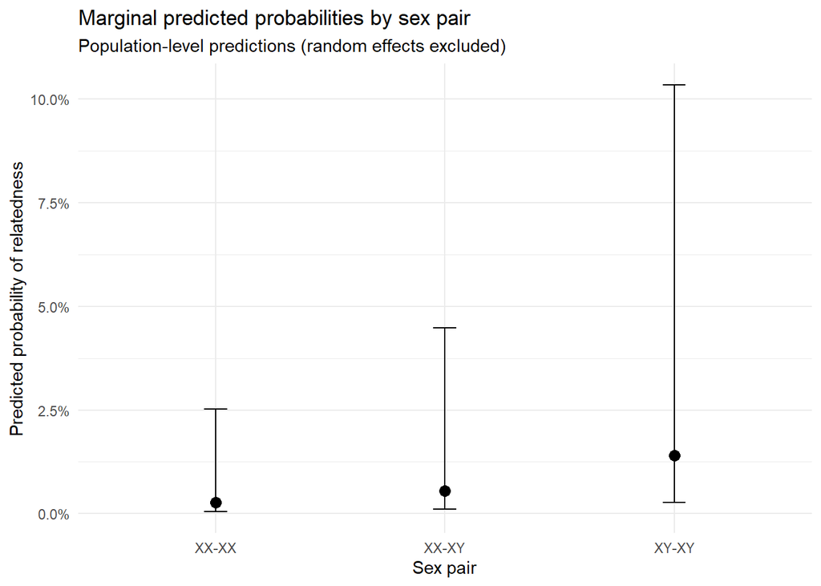

```r
ggplot(pp_group_sex, aes(x = sex_pair, y = estimate)) +
  geom_point(size = 3) +
  geom_errorbar(
    aes(ymin = conf.low, ymax = conf.high),
    width = 0.1
  ) +
  scale_y_continuous(
    labels = scales::percent_format(accuracy = 0.1)
  ) +
  labs(
    x = "Sex pair",
    y = "Predicted probability of relatedness",
    title = "Marginal predicted probabilities by sex pair",
    subtitle = "Population-level predictions (random effects excluded)"
  ) +
  theme_minimal()
```

2. each age_pair category

```r
pp_group_age <- avg_predictions(
  model = imp_binary_group_cat,
  by = "age_pair",
  type = "response",
  newdata = pairs_group,
  re_formula = NA,
  allow_new_levels = TRUE
)

pp_group_age
```

```
##
##              age_pair Estimate   2.5 % 97.5 %
##  both adult/undefined  0.00609 0.00110 0.0514
##  both subadult         0.01413 0.00247 0.1011
##  mixed                 0.00769 0.00146 0.0595
##
## Type: response
```

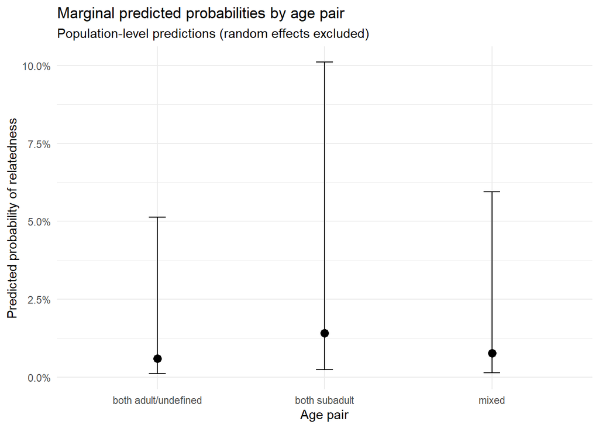

```r
ggplot(pp_group_age, aes(x = age_pair, y = estimate)) +
  geom_point(size = 3) +
  geom_errorbar(
    aes(ymin = conf.low, ymax = conf.high),
    width = 0.1
  ) +
  scale_y_continuous(
    labels = scales::percent_format(accuracy = 0.1)
  ) +
  labs(
    x = "Age pair",
    y = "Predicted probability of relatedness",
    title = "Marginal predicted probabilities by age pair",
    subtitle = "Population-level predictions (random effects excluded)"
  ) +
  theme_minimal()
```

3. each bone_quality category

```r
pp_group_bone <- avg_predictions(
  model = imp_binary_group_cat,
  by = "bone_quality",
  type = "response",
  newdata = pairs_group,
  re_formula = NA,
  allow_new_levels = TRUE
)

pp_group_bone
```

```
##
##  bone_quality Estimate    2.5 % 97.5 %
##     high-high  0.01017 0.001885 0.0839
##     high-low   0.00478 0.000897 0.0391
##     low-low    0.00905 0.001391 0.0647
##
## Type: response
```

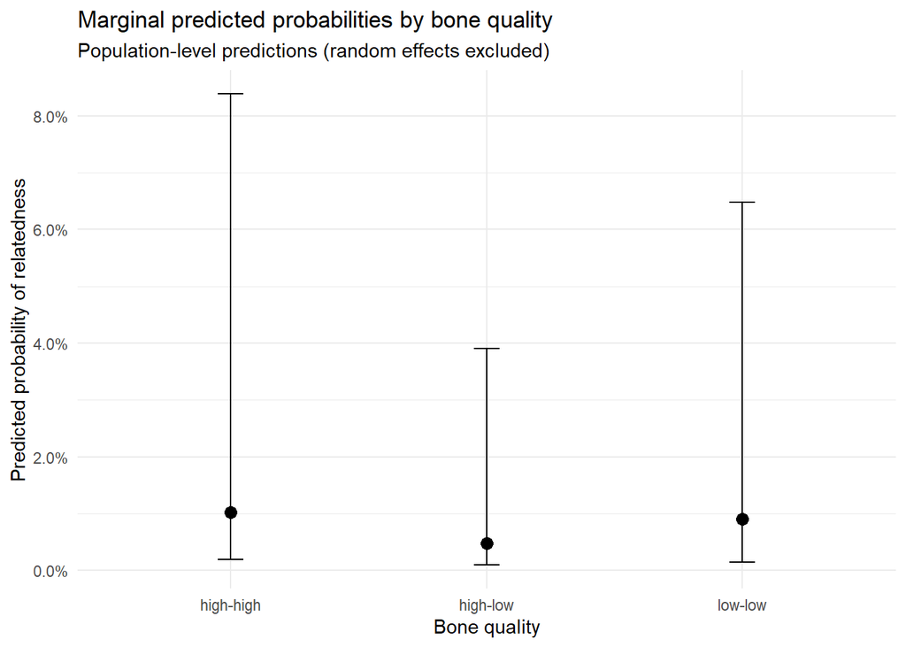

```r
ggplot(pp_group_bone, aes(x = bone_quality, y = estimate)) +
  geom_point(size = 3) +
  geom_errorbar(
    aes(ymin = conf.low, ymax = conf.high),
    width = 0.1
  ) +
  scale_y_continuous(
    labels = scales::percent_format(accuracy = 0.1)
  ) +
  labs(
    x = "Bone quality",
    y = "Predicted probability of relatedness",
    title = "Marginal predicted probabilities by bone quality",
    subtitle = "Population-level predictions (random effects excluded)"
  ) +
  theme_minimal()
```

4. each same_tomb category?

```r
pp_group_tomb <- avg_predictions(
  model = imp_binary_group_cat,
  by = "same_tomb",
  type = "response",
  newdata = pairs_group,
  re_formula = NA,
  allow_new_levels = TRUE
)

pp_group_tomb
```

```
##
##  same_tomb Estimate    2.5 % 97.5 %
##      FALSE   0.0016 0.000289 0.0148
##       TRUE   0.0203 0.004003 0.1505
##
## Type: response
```

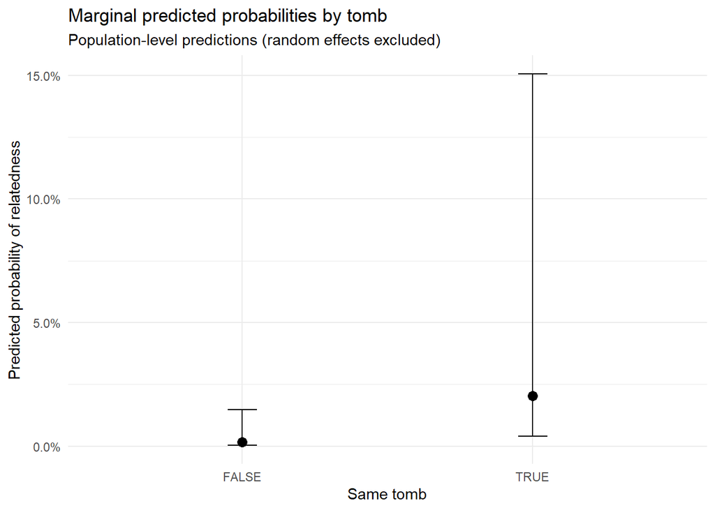

```r
ggplot(pp_group_tomb, aes(x = same_tomb, y = estimate)) +
  geom_point(size = 3) +
  geom_errorbar(
    aes(ymin = conf.low, ymax = conf.high),
    width = 0.1
  ) +
  scale_y_continuous(
    labels = scales::percent_format(accuracy = 0.1)
  ) +
  labs(
    x = "Same tomb",
    y = "Predicted probability of relatedness",
    title = "Marginal predicted probabilities by tomb",
    subtitle = "Population-level predictions (random effects excluded)"
  ) +
  theme_minimal()
```

**“By how many percentage points does the probability change compared to the reference?”**

```r
new_data <- imp_binary_group_cat$data
```

1. sex pair

```r
cmp_group_sex <- avg_comparisons(
  imp_binary_group_cat,
  variables = "sex_pair",
  type = "response",
  newdata = new_data,
  re_formula = NA,
  allow_new_levels = TRUE
)
cmp_group_sex
```

```
##
##       Contrast Estimate    2.5 % 97.5 %
##  XX-XY - XX-XX  0.00301 0.000164 0.0261
##  XY-XY - XX-XX  0.01288 0.002268 0.0912
##
## Term: sex_pair
## Type: response
```

2. age pair

```r
cmp_group_age <- avg_comparisons(
  imp_binary_group_cat,
  variables = "age_pair",
  type = "response",
  newdata = new_data,
  re_formula = NA,
  allow_new_levels = TRUE
)
cmp_group_age
```

```
##
##                              Contrast Estimate     2.5 % 97.5 %
##  both subadult - both adult/undefined  0.01495  0.001597 0.0950
##  mixed - both adult/undefined          0.00346 -0.000379 0.0273
##
## Term: age_pair
## Type: response
```

3. bone quality

```r
cmp_group_bone <- avg_comparisons(
  imp_binary_group_cat,
  variables = "bone_quality",
  type = "response",
  newdata = new_data,
  re_formula = NA,
  allow_new_levels = TRUE
)
cmp_group_bone
```

```
##
##              Contrast Estimate   2.5 %  97.5 %
##  high-low - high-high -0.00213 -0.0254 0.00225
##  low-low - high-high   0.00372 -0.0130 0.03462
##
## Term: bone_quality
## Type: response
```

4. same tomb

```r
cmp_group_tomb <- avg_comparisons(
  imp_binary_group_cat,
  variables = "same_tomb",
  type = "response",
  newdata = new_data,
  re_formula = NA,
  allow_new_levels = TRUE
)
cmp_group_tomb
```

```
##
##  Estimate  2.5 % 97.5 %
##    0.0194 0.0038   0.14
##
## Term: same_tomb
## Type: response
## Comparison: TRUE - FALSE
```